# Cluster Analysis for Crime Data

Clustering INSOFE Lab Assignment

16 July 2017

**NOTE** Before starting this assignment please remember to clear your environment, you can do that by running the following code chunk

```r
rm(list=ls(all=TRUE))
```

# Agenda

- Get the data
- Data pre-processing
- Explore the data
- Hierarchical Clustering
- Kmeans Clustering
- Visualising Clusters and Evaluation

# Problem Description

- In the following Unsupervised Learning activity, you will perform cluster analysis on a dataset that has arrests per 100,000 residents for assault, murder, and rape in each of the 50 US states
- The variable names in the dataset are self explanatory
- So, you will cluster US states based on the crime rates, which can then be passed on to public policy experts to gain insight from it

# Reading & Understanding the Data

- Read in the dataset

```r
# Use the setwd() function to get to the directory where the data is present

setwd("C:\\insofe\\day13\\20170716_Batch30_CSE7305c_ClusterAnalysis_FullLab")

cluster_data=read.csv("crime_data.csv")
```

- Use the str() and summary() functions to get a feel for the dataset.

```r
str(cluster_data)
```

```
## 'data.frame':    50 obs. of  5 variables:
##  $ State   : Factor w/ 50 levels "Alabama","Alaska",..: 1 2 3 4 5 6 7 8 9 10 ...
##  $ Murder  : num  13.2 10 8.1 8.8 9 7.9 3.3 5.9 15.4 17.4 ...
##  $ Assault : int  236 263 294 190 276 204 110 238 335 211 ...
##  $ UrbanPop: int  58 48 80 50 91 78 77 72 80 60 ...
##  $ Rape    : num  21.2 44.5 31 19.5 40.6 38.7 11.1 15.8 31.9 25.8 ...
```

```r
summary(cluster_data)
```

```
##         State        Murder          Assault         UrbanPop
##  Alabama   : 1   Min.   : 0.800   Min.   : 45.0   Min.   :32.00
##  Alaska    : 1   1st Qu.: 4.075   1st Qu.:109.0   1st Qu.:54.50
##  Arizona   : 1   Median : 7.250   Median :159.0   Median :66.00
##  Arkansas  : 1   Mean   : 7.788   Mean   :170.8   Mean   :65.54
##  California: 1   3rd Qu.:11.250   3rd Qu.:249.0   3rd Qu.:77.75
##  Colorado  : 1   Max.   :17.400   Max.   :337.0   Max.   :91.00
##  (Other)   :44
##       Rape
##  Min.   : 7.30
##  1st Qu.:15.07
##  Median :20.10
##  Mean   :21.23
##  3rd Qu.:26.18
##  Max.   :46.00
##
```

- Take a look at the data using the “head()” and “tail()” functions

```r
head(cluster_data)
```

```
##        State Murder Assault UrbanPop Rape
## 1    Alabama   13.2     236       58 21.2
## 2     Alaska   10.0     263       48 44.5
## 3    Arizona    8.1     294       80 31.0
## 4   Arkansas    8.8     190       50 19.5
## 5 California    9.0     276       91 40.6
## 6   Colorado    7.9     204       78 38.7
```

```r
tail(cluster_data)
```

```
##            State Murder Assault UrbanPop Rape
## 45       Vermont    2.2      48       32 11.2
## 46      Virginia    8.5     156       63 20.7
## 47    Washington    4.0     145       73 26.2
## 48 West Virginia    5.7      81       39  9.3
## 49     Wisconsin    2.6      53       66 10.8
## 50       Wyoming    6.8     161       60 15.6
```

# Data pre-processing

- Check for the number of missing values in the dataset

```r
sum(is.na(cluster_data))
```

```
## [1] 0
```

- Convert the State names into row names and remove that variable from the dataset

```r
rownames(cluster_data)=cluster_data$State
cluster_data_rm <- cluster_data[, -c(colnames(cluster_data) %in% ("State"))]
```

- Standardize and scale the data

```r
cluster_data_scaled <- scale(cluster_data_rm, center = T, scale = T)
```

# Data exploration

- Visualise the distances between the individual observations using the fviz_dist()

```r
library(factoextra)
```

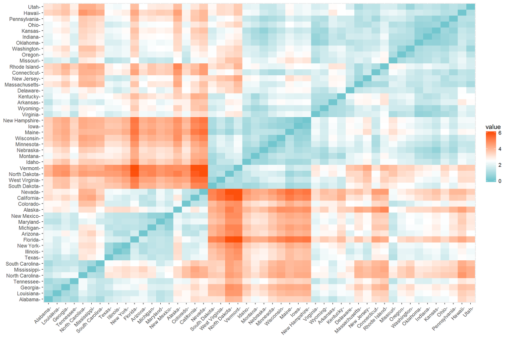

```r
distance <- get_dist(cluster_data_scaled)
fviz_dist(distance, gradient = list(low = "#00AFBB", mid = "white", high = "#FC4E07"))
```

# Hierarchical Clustering

- Cluster the data using the Ward algorithm

```r
# We use the euclidean distance measure

dist <- dist(cluster_data_scaled, method = "euclidean")

hc_fit <- hclust(dist, method = "ward.D2")
```

- Plot the dendogram for hierarchical clustering

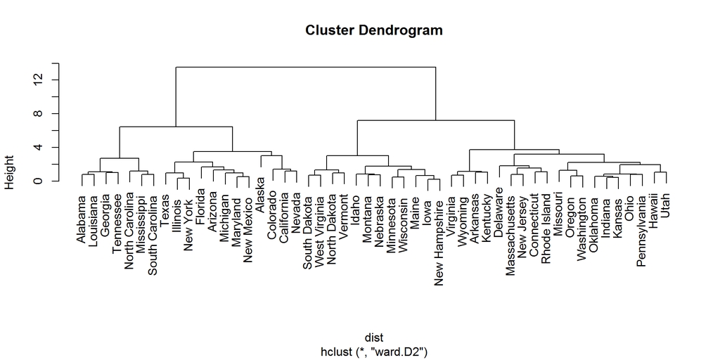

```r
plot(hc_fit)
```

- Cut the tree to 4 clusters

```r
points_hc <- cutree(hc_fit, k = 4)

# Store the clusters in a data frame along with the crime data

Crime_clust_hc <- cbind(points_hc, cluster_data_scaled)

# Have a look at the head of the new data frame

colnames(Crime_clust_hc)[1] <- "cluster_hc"

head(Crime_clust_hc)
```

```
##            cluster_hc     Murder   Assault   UrbanPop         Rape
## Alabama             1 1.24256408 0.7828393 -0.5209066 -0.003416473
## Alaska              2 0.50786248 1.1068225 -1.2117642  2.484202941
## Arizona             2 0.07163341 1.4788032  0.9989801  1.042878388
## Arkansas            3 0.23234938 0.2308680 -1.0735927 -0.184916602
## California          2 0.27826823 1.2628144  1.7589234  2.067820292
## Colorado            2 0.02571456 0.3988593  0.8608085  1.864967207
```

- Plot a new dendogram, with each of the clusters being surrounded by a border, using the rect.hclust() function

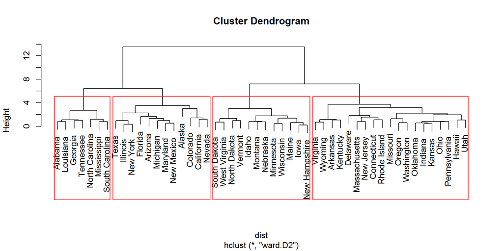

```r
plot(hc_fit)
rect.hclust(hc_fit, k = 4, border = "red")
```

# K-Means Clustering

- Build a basic kmeans model with k = 2

```r
set.seed(123)
km_basic <- kmeans(cluster_data_scaled, centers = 2)

str(km_basic)
```

```
## List of 9
##  $ cluster     : Named int [1:50] 2 2 2 1 2 2 1 1 2 2 ...
##   ..- attr(*, "names")= chr [1:50] "Alabama" "Alaska" "Arizona" "Arkansas" ...
##  $ centers     : num [1:2, 1:4] -0.67 1.005 -0.676 1.014 -0.132 ...
##   ..- attr(*, "dimnames")=List of 2
##   .. ..$ : chr [1:2] "1" "2"
##   .. ..$ : chr [1:4] "Murder" "Assault" "UrbanPop" "Rape"
##  $ totss       : num 196
##  $ withinss    : num [1:2] 56.1 46.7
##  $ tot.withinss: num 103
##  $ betweenss   : num 93.1
##  $ size        : int [1:2] 30 20
##  $ iter        : int 1
##  $ ifault      : int 0
##  - attr(*, "class")= chr "kmeans"
```

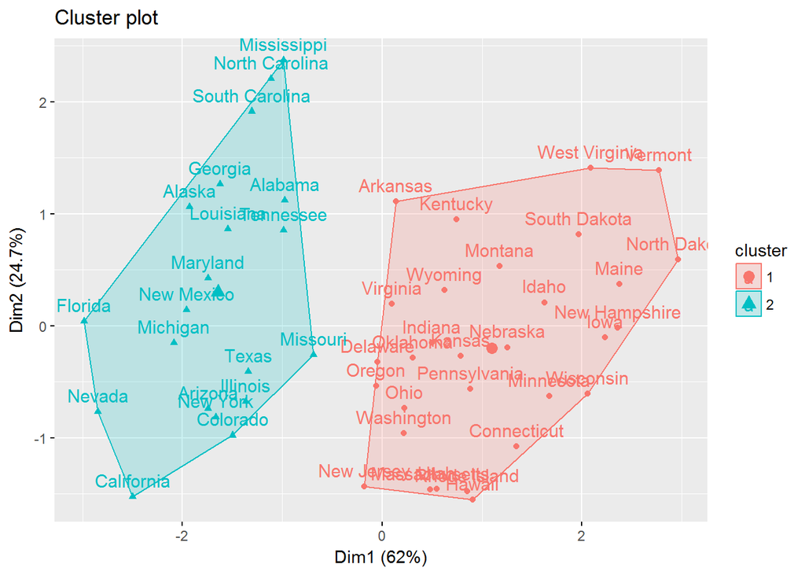

```r
fviz_cluster(km_basic, cluster_data_scaled)
```

- Build a scree plot and choose a “k”

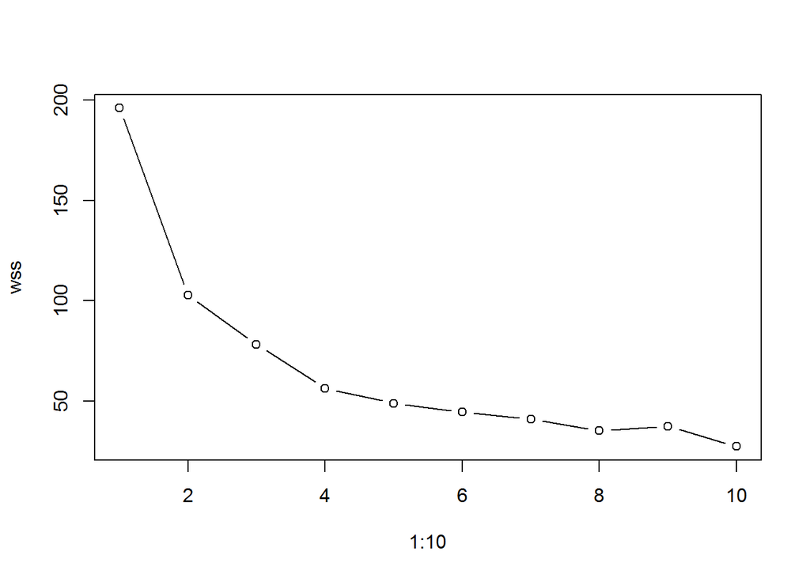

```r
# Initialize wss to 0

wss <- 0

# From 1 upto upto 10 cluster centers, fit the kmeans model

for (i in 1:10) {

  cfit = kmeans(cluster_data_scaled, centers = i)

  # Store the sum of within sum of square

  wss[i] <- sum(cfit$withinss)

}
plot(1:10, wss, type = "b")
```

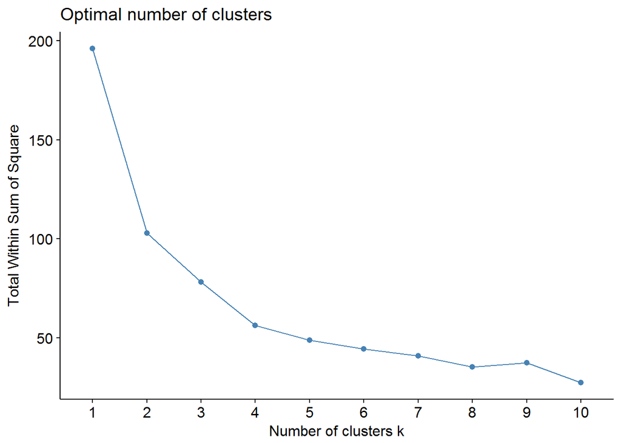

```r
set.seed(123)

fviz_nbclust(cluster_data_scaled, kmeans, method = "wss")
```

- Choose a k and cluster the data

```r
# We can choose a k = 4, 5 or 6


km_clust <- kmeans(cluster_data_scaled, 6, nstart = 10)

# after choosing k as 6, let's store the cluster groupings along with the data in a new data frame

km_points <- km_clust$cluster

# Store the cluster assignments in a new data frame

crime_clusts_km <- as.data.frame(cbind(km_clust$cluster, cluster_data_scaled))

# Look at the head of the data

head(crime_clusts_km)
```

```
##            V1     Murder   Assault   UrbanPop         Rape
## Alabama     2 1.24256408 0.7828393 -0.5209066 -0.003416473
## Alaska      6 0.50786248 1.1068225 -1.2117642  2.484202941
## Arizona     3 0.07163341 1.4788032  0.9989801  1.042878388
## Arkansas    5 0.23234938 0.2308680 -1.0735927 -0.184916602
## California  6 0.27826823 1.2628144  1.7589234  2.067820292
## Colorado    6 0.02571456 0.3988593  0.8608085  1.864967207
```

```r
colnames(crime_clusts_km)[1] <- "cluster_km"
```

- Visualise the clusters by plotting the data points on the first two principal components

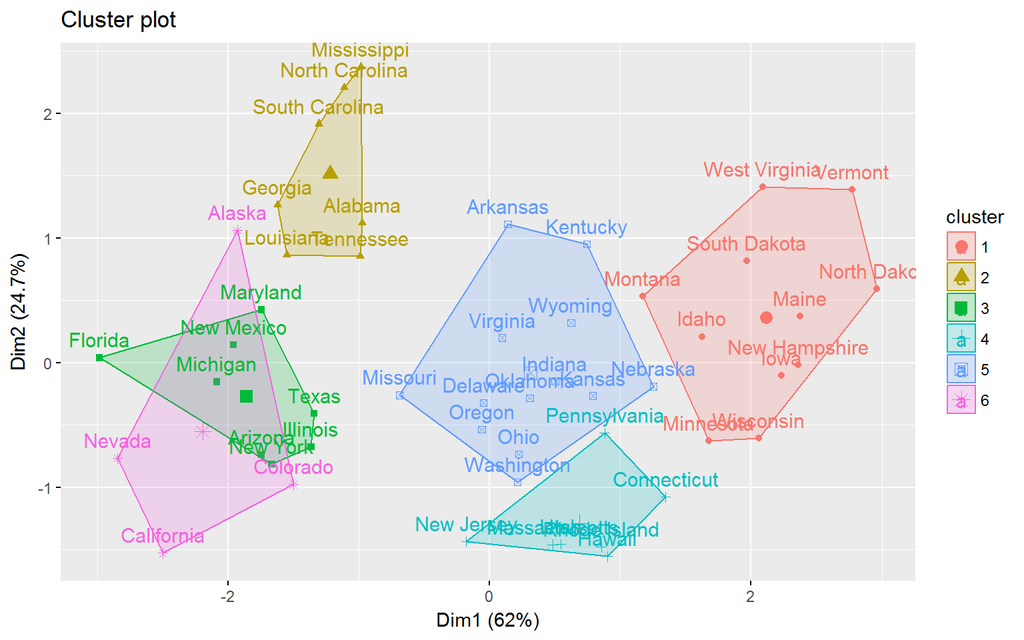

```r
fviz_cluster(km_clust, cluster_data_scaled)
```